# 5_06_assignment_crutchfield

Russell Crutchfield

10/16/2019

## Assignment for Week 9 / Modules 5 and 6 (Merged and consolidated)

#In this assignment, you’ll be asked to predict reading scores using the ELS data.

## Load Data File

```r
load("~/Desktop/Fall 2019/Data Science/GitHub Projects/data_science/LLO8200/els_train.RData")

load("~/Desktop/Fall 2019/Data Science/GitHub Projects/data_science/LLO8200/els.RData")

load("~/Desktop/Fall 2019/Data Science/GitHub Projects/data_science/LLO8200/els_test.RData")
```

## 1. Choose a dependent variable and plot that dependent variable as a function of a continuous independent variable.

#Use ggplot

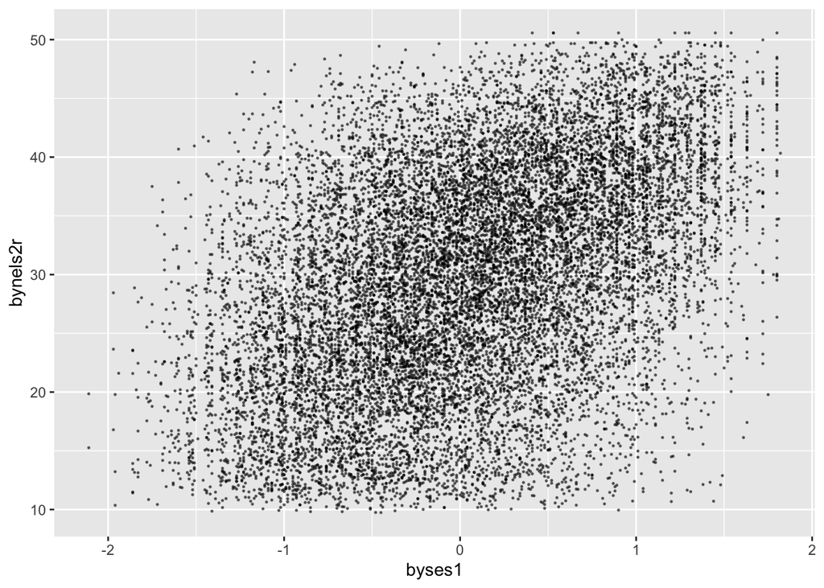

```r
gg <- ggplot(els, aes(x=byses1, y=bynels2r)) + geom_point(alpha=0.50, size=0.25)
gg
```

## 2. If you need to, adjust the scale of either the dependent variable or independent variable to make more sense.

#Yes – try this and show the results (even if it makes the plot “worse”).

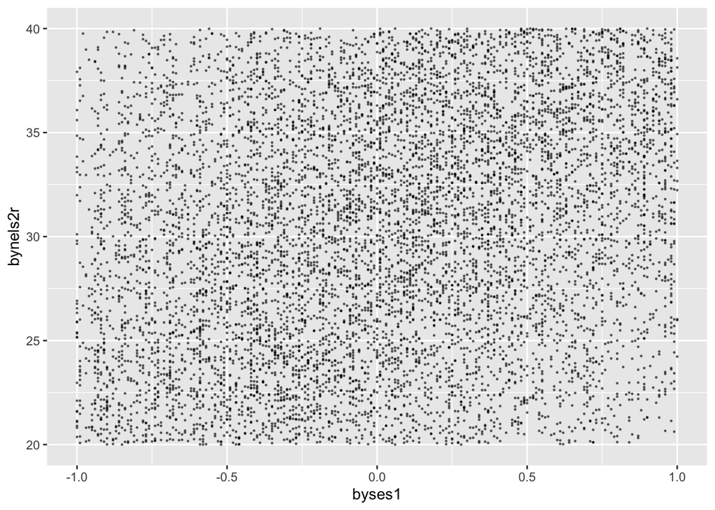

```r
#adjust the scale

gg1 <- gg + xlim(c(-1,1)) + ylim(c(20,40))
gg1
```

## 3. Add a line of best fit to your graphic.

# Show both the loess and lm lines. Hint: Use geom smooth.

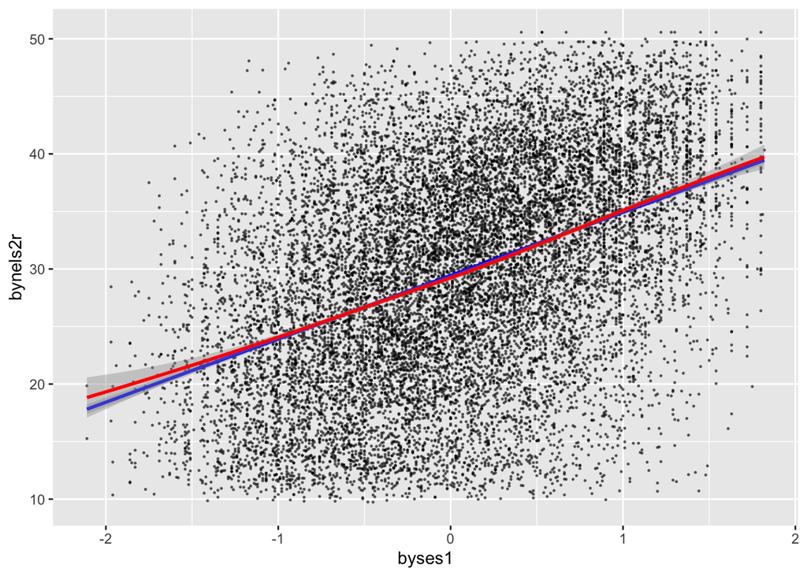

```r
gg <- gg + geom_smooth(method = "lm", color = "blue")
gg <- gg + geom_smooth(method = "loess", color = "red")
gg
```

## 4. Clean up the labeling and description of the graphic so that it could be presented to a broader audience.

#Make it pretty. Hint: Investigate the resources for ggplot and find which parameters can be altered for aesthetics.

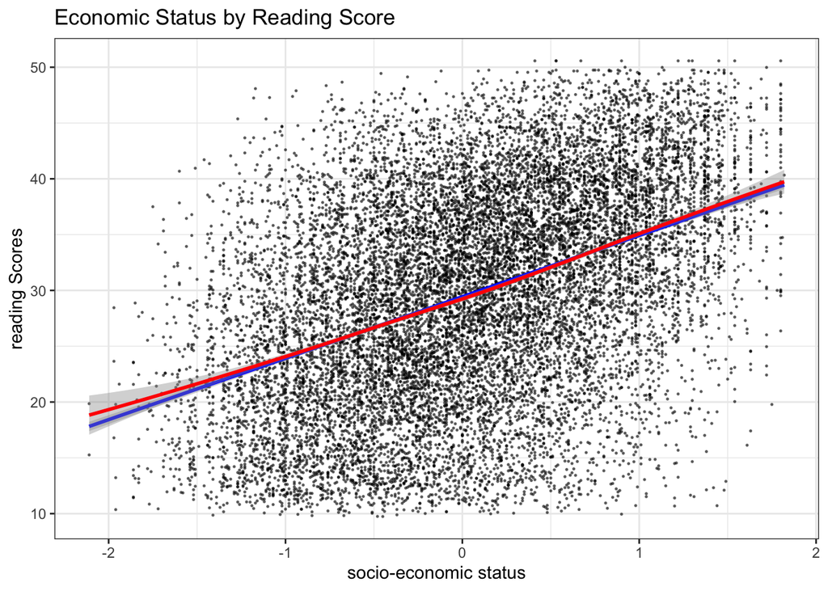

```r
gg <- gg + xlab("socio-economic status") + ylab("reading Scores") + ggtitle ("Economic Status by Reading Score") + theme_bw()
gg
```